# Chapter 3 Problem Summary

## SETUP

```r
#setwd("/Users/anjali/Documents/university/Econ_5305/code_directory/Chapter3")
rm(list = ls())
```

```r
library(readxl)
library(ggplot2)
library(dynlm)
```

## QUESTION 1

```r
q1_data <- read_excel("q1_data.xls")
View(q1_data)
```

#### EDA

1. Plot Real personal consumption and real personal income

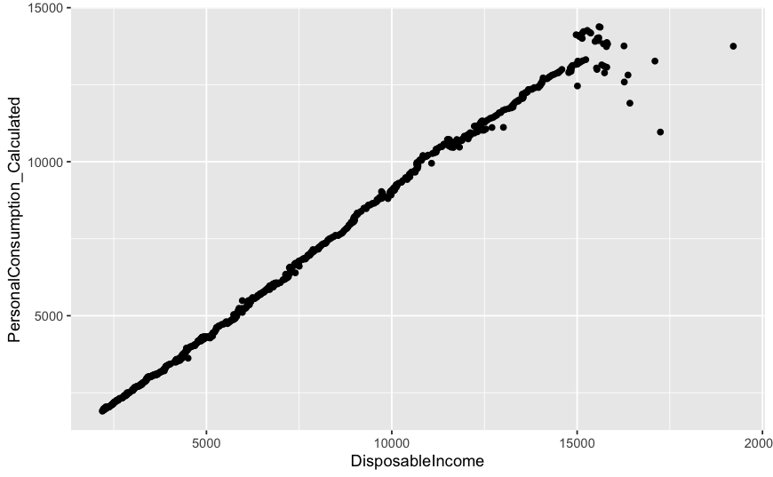

```r
# Scatter plot
ggplot(q1_data,aes(x=DisposableIncome, y=PersonalConsumption_Calculated)) + geom_point()
```

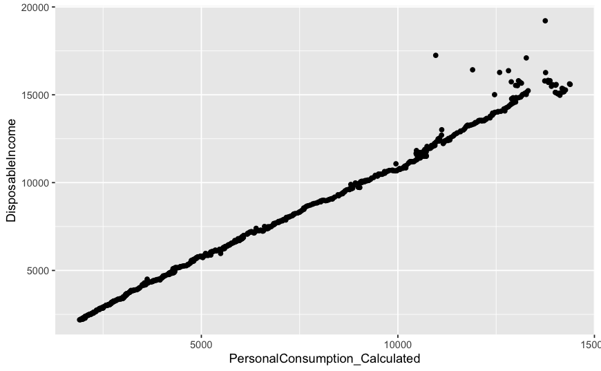

```r
ggplot(q1_data,aes(x=PersonalConsumption_Calculated, y=DisposableIncome)) + geom_point()
```

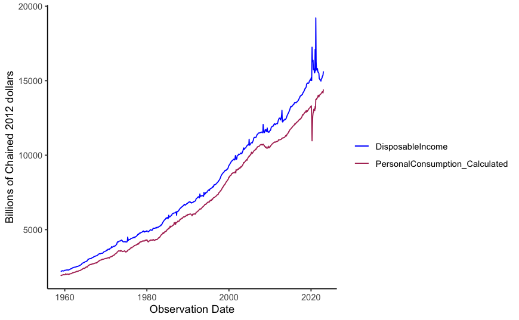

```r
# Line plot
ggplot( q1_data, aes(x = observation_date )) +
  #add one line for Export
  geom_line(aes(y = DisposableIncome , colour = "DisposableIncome") ) +
  # add another line for Import
  geom_line(aes(y = PersonalConsumption_Calculated , colour = "PersonalConsumption_Calculated")) +
  theme_classic() +
  scale_color_manual(name = '',
                       breaks = c( "DisposableIncome" , "PersonalConsumption_Calculated" ),
                       values = c( "DisposableIncome" =  'blue' ,
                                   "PersonalConsumption_Calculated" = 'maroon' )
                       ) +
  ylab( "Billions of Chained 2012 dollars") +
  xlab("Observation Date")
```

**Key Findings:**

- Both series have clear upward trends and are not stationary as the mean is not constant.
- They appear to move in the same direction and at similar slopes.
- However, you can see that in 2020 disposable income shot up but personal consumption went down in opposite direction this is interesting phenomenon.
- Consumption is always lower than disposable income which makes sense since consumption is typically a portion of income.

### Part a. Calculate growth rates of real consumption and disposable personal income.

```r
T_CONSUMPTION<-ts(q1_data$PersonalConsumption_Calculated,frequency=12,start=c(1959))
T_INCOME <- ts(q1_data$DisposableIncome,frequency=12,start=c(1959))

# calculate growth rates by taking the difference of the log (natural log)
G_CONSUMPTION <- 100*diff(log(T_CONSUMPTION))
G_INCOME <- 100*diff(log(T_INCOME))
```

```r
summary(G_CONSUMPTION)
```

```
    Min.  1st Qu.   Median     Mean  3rd Qu.     Max.
-12.7984   0.0000   0.2722   0.2630   0.5982   8.2081
```

```r
summary(G_INCOME)
```

```
     Min.   1st Qu.    Median      Mean   3rd Qu.      Max.
-16.66369   0.02019   0.26941   0.25540   0.48342  20.43519
```

```r
cat( "Standard deviation for Consumption Growth: ", sd(G_CONSUMPTION),"\nStandard deviation for Personal Income Growth:", sd(G_INCOME))
```

```
Standard deviation for Consumption Growth:  0.8376636
Standard deviation for Personal Income Growth: 1.391292
```

```r
cat ("\nLinear correlation between the two series: ", cor(G_CONSUMPTION,G_INCOME))
```

```
Linear correlation between the two series:  -0.04348076
```

**Note**: The standard deviation of Personal Income Growth is higher than Personal Consumption Growth. This indicates that volatility is higher for Personal Income Growth as compared to Consumption Growth. We also see that the mean is very similar for the two as well and close to zero.

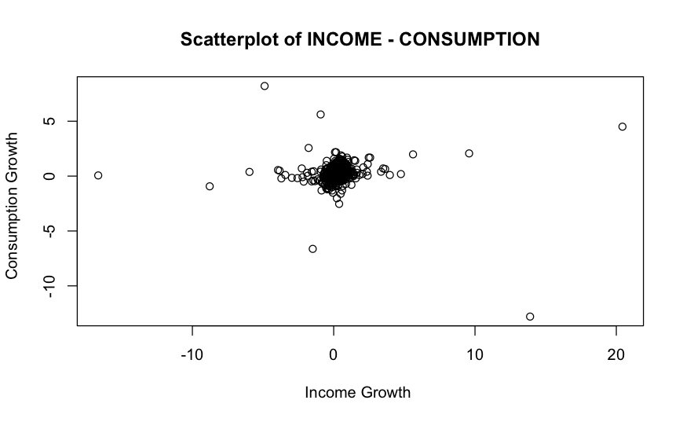

```r
# Scatter plot

plot(G_INCOME, G_CONSUMPTION, main="Scatterplot of INCOME - CONSUMPTION",
   xlab="Income Growth ", ylab="Consumption Growth  ")
```

```r
# Line plot
plot(G_INCOME, type ='l',col = "blue" , xlab= "observation_date", ylab = "Growth Percentage")
lines(G_CONSUMPTION, type = 'l', col = "red")
```

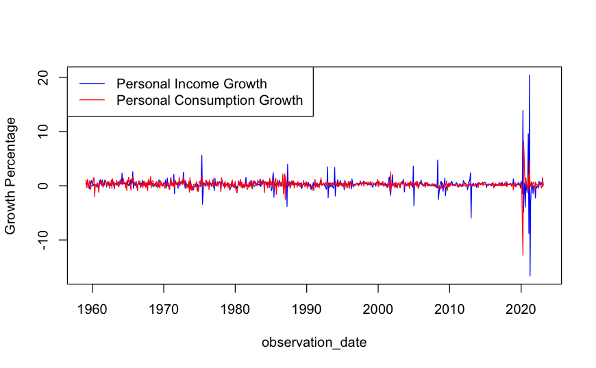

```r
legend("topleft", c("Personal Income Growth ","Personal Consumption Growth ") ,lty = 1, col = c("blue","red"))
```

**Observations:** The time series graph clearly shows that Income Growth is much more volatile. Additionally, we can see that after performing the log difference transformation the growth series is weakly stationary. Constant mean, near constant variance, except for some periods such as COVID-19, 2008 recession, etc. (shock events).

**Explaining Volatility in Income vs. Consumption:** Over time, the growth in disposable income has exhibited greater volatility compared to the growth in personal consumption. Personal consumption growth tends to move within a certain range, regardless of whether disposable income increases or decreases, which aligns with the permanent income model(= individuals base their consumption patterns on their long-term, or permanent, income rather than their current income). However, during the pandemic, personal consumption experienced a significant decline. This does not necessarily signify a break in the **permanent income model**, but rather a result of the significant changes in our lifestyles due to quarantine and social distancing measures.

In addition, COVID-19 may have also made people feel uncertain in terms of their future permanent income prospects and this along with lifestyle changes could have caused consumption to decline.

#### Part b: Regression (Contemporaneous Correlation)

Regress consumption growth on disposable income growth. Interpret the estimated resulted

```r
model_1a <- dynlm(G_CONSUMPTION ~ G_INCOME)
summary(model_1a)
```

```
Time series regression with "ts" data:
Start = 1959(2), End = 2023(2)

Call:
dynlm(formula = G_CONSUMPTION ~ G_INCOME)

Residuals:
     Min       1Q   Median       3Q      Max
-12.7042  -0.2672   0.0079   0.3207   7.8105

Coefficients:
            Estimate Std. Error t value Pr(>|t|)
(Intercept)  0.26964    0.03070   8.782   <2e-16 ***
G_INCOME    -0.02618    0.02172  -1.205    0.228
---
Signif. codes:  0 ‘***’ 0.001 ‘**’ 0.01 ‘*’ 0.05 ‘.’ 0.1 ‘ ’ 1

Residual standard error: 0.8374 on 767 degrees of freedom
Multiple R-squared:  0.001891,  Adjusted R-squared:  0.0005893
F-statistic: 1.453 on 1 and 767 DF,  p-value: 0.2284
```

```r
#plot(model_1a)
```

Interestingly the intercept value has very high significance which can be explored further.

#### Part c: (OLS Models with Lag)

##### Model 1: Single Lag

```r
model_1b<-dynlm(G_CONSUMPTION ~ G_INCOME + stats::lag(G_INCOME,-1))
summary(model_1b)
```

```
Time series regression with "ts" data:
Start = 1959(3), End = 2023(2)

Call:
dynlm(formula = G_CONSUMPTION ~ G_INCOME + stats::lag(G_INCOME,
    -1))

Residuals:
     Min       1Q   Median       3Q      Max
-12.8692  -0.2671   0.0001   0.3153   7.4087

Coefficients:
                          Estimate Std. Error t value Pr(>|t|)
(Intercept)               0.255254   0.032055   7.963 6.07e-15 ***
G_INCOME                 -0.009442   0.024557  -0.384    0.701
stats::lag(G_INCOME, -1)  0.035837   0.024557   1.459    0.145
---
Signif. codes:  0 ‘***’ 0.001 ‘**’ 0.01 ‘*’ 0.05 ‘.’ 0.1 ‘ ’ 1

Residual standard error: 0.8369 on 765 degrees of freedom
Multiple R-squared:  0.004667,  Adjusted R-squared:  0.002064
F-statistic: 1.793 on 2 and 765 DF,  p-value: 0.1671
```

```r
#plot(model_1b)
```

**Interpretation of the Model:** Although adding lagged Disposable Income growth, the model is still not significant at the 5% level and have 0.2064% of adjusted R-squared. When 1% of Disposable Income growth increase associated with 0.009442% of personal consume logged growth decrease controlling lagged disposable income growth. Also when 1% of lagged Disposable Income growth increase associated with 0.0356% of personal consume logged growth increase controlling personal consume logged growth.

##### Model 2: Mutliple Lags

```r
model_1c<-dynlm(G_CONSUMPTION ~ stats::lag(G_INCOME,-1) + stats::lag(G_INCOME,-2) + stats::lag(G_INCOME,-3) + stats::lag(G_INCOME,-4))
summary(model_1c)
```

```
Time series regression with "ts" data:
Start = 1959(6), End = 2023(2)

Call:
dynlm(formula = G_CONSUMPTION ~ stats::lag(G_INCOME, -1) + stats::lag(G_INCOME,
    -2) + stats::lag(G_INCOME, -3) + stats::lag(G_INCOME, -4))

Residuals:
     Min       1Q   Median       3Q      Max
-12.9816  -0.2829   0.0121   0.2980   6.8971

Coefficients:
                         Estimate Std. Error t value Pr(>|t|)
(Intercept)               0.17295    0.03455   5.006 6.92e-07 ***
stats::lag(G_INCOME, -1)  0.09142    0.02426   3.768 0.000177 ***
stats::lag(G_INCOME, -2)  0.13773    0.02718   5.067 5.08e-07 ***
stats::lag(G_INCOME, -3)  0.09299    0.02718   3.421 0.000657 ***
stats::lag(G_INCOME, -4)  0.02397    0.02427   0.987 0.323747
---
Signif. codes:  0 ‘***’ 0.001 ‘**’ 0.01 ‘*’ 0.05 ‘.’ 0.1 ‘ ’ 1

Residual standard error: 0.8237 on 760 degrees of freedom
Multiple R-squared:  0.03918,   Adjusted R-squared:  0.03412
F-statistic: 7.748 on 4 and 760 DF,  p-value: 4.027e-06
```

```r
#plot(model_1c)
```

**Interpretation of the model** By adding more lag period from -1 to -4 we see that the we are able to get a statistically significant mode. The F-statistic is high at 7.748 with a very small p-value. Of the 4 coefficients in the we see that B1,B2,B3 are also highly statistically significant upto 99% confidence. B4 however is is not statistically significant. This indicates that there is an adjustment lag between income and consumption. People tend to consume based on their past income up-to about 3 period prior (3-months ago).

## QUESTION 2

#### Load Data

```r
q2_data <- read_excel("q2_data_v2.xls")
View(q2_data)
T_CPI<-ts(q2_data$CPI,frequency=12,start=c(1960))
T_TB3MS <- ts(q2_data$TB3MS,frequency=12,start=c(1960))
```

#### EDA on CPI and 3 Month Treasury Bill Rate

```r
summary(T_CPI)
```

```
   Min. 1st Qu.  Median    Mean 3rd Qu.    Max.    NA's
  12.39   23.16   57.46   57.15   86.87  126.80       2
```

```r
summary(T_TB3MS)
```

```
   Min. 1st Qu.  Median    Mean 3rd Qu.    Max.
  0.010   1.860   4.460   4.359   6.030  16.300
```

```r
cat( "Standard deviation for Consumption Growth: ", sd(T_CPI),"\nStandard deviation for Personal Income Growth:", sd(T_TB3MS))
```

```
Standard deviation for Consumption Growth:  NA
Standard deviation for Personal Income Growth: 3.185337
```

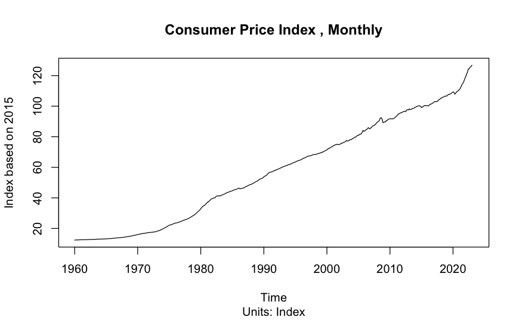

```r
plot.ts( T_CPI, main = "Consumer Price Index , Monthly", sub = "Units: Index", ylab = "Index based on 2015")
```

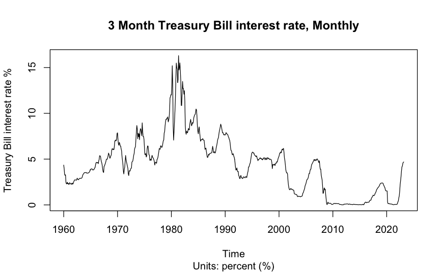

```r
plot.ts( T_TB3MS, main = "3 Month Treasury Bill interest rate, Monthly", sub = "Units: percent (%)", ylab = "Treasury Bill interest rate %")
```

```r
# calculate monthly inflation by calculating the difference of log
monthly_inflation <- 100*diff(log(T_CONSUMPTION))

# calculate expost real interest rate
expost_real_interest_rate <- T_TB3MS - monthly_inflation
```

```r
# Print the summary statistics of inflation and real interest rate
cat("Summary Statistics for Monthly Inflation:\n")
```

```
Summary Statistics for Monthly Inflation:
```

```r
summary(monthly_inflation)
```

```
    Min.  1st Qu.   Median     Mean  3rd Qu.     Max.
-12.7984   0.0000   0.2722   0.2630   0.5982   8.2081
```

```r
cat("\nSummary Statistics for Real Interest Rate:\n")
```

```
Summary Statistics for Real Interest Rate:
```

```r
summary(expost_real_interest_rate)
```

```
   Min. 1st Qu.  Median    Mean 3rd Qu.    Max.
 -8.078   1.706   3.997   4.096   5.746  16.300
```

#### Add real interest rate to equation 1b

```r
# Line plot
plot(expost_real_interest_rate, type ='l',col = "green" , xlab= "observation_date", ylab = "Growth Percentage / Rate  - (%)")
lines(G_INCOME, type = 'l', col = "blue")
```

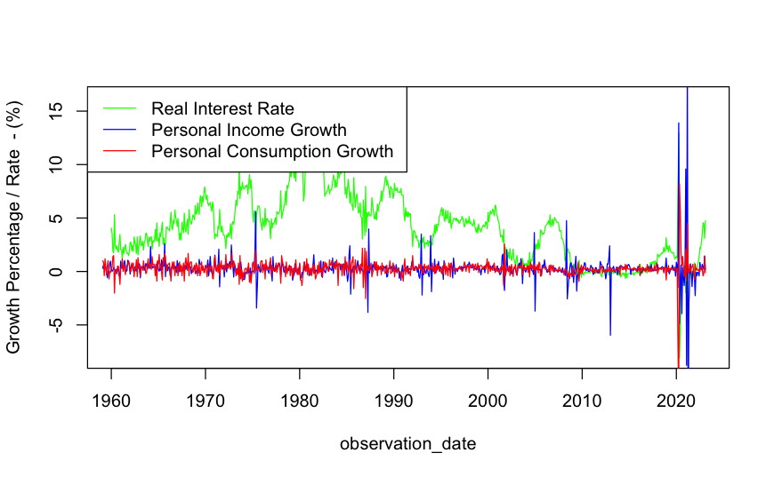

```r
lines(G_CONSUMPTION, type = 'l', col = "red")
legend("topleft", c("Real Interest Rate","Personal Income Growth ","Personal Consumption Growth ") ,lty = 1, col = c("green","blue","red"))
```

**Observations:** We can see the the negative real interest rates that were maintained by the government during COVID-19 shock to possibly improve the low consumption and give respite to businesses.

#### Regress consumption growth on disposable income growth and Real Interest Rate. Interpret the estimated resulted

```r
model_2 <- dynlm(G_CONSUMPTION ~ G_INCOME + expost_real_interest_rate)
summary(model_2)
```

```
Time series regression with "ts" data:
Start = 1960(1), End = 2023(2)

Call:
dynlm(formula = G_CONSUMPTION ~ G_INCOME + expost_real_interest_rate)

Residuals:
     Min       1Q   Median       3Q      Max
-12.1626  -0.3282  -0.0335   0.3095   7.0195

Coefficients:
                          Estimate Std. Error t value Pr(>|t|)
(Intercept)                0.54030    0.04719  11.450  < 2e-16 ***
G_INCOME                  -0.02270    0.02106  -1.078    0.281
expost_real_interest_rate -0.06652    0.00893  -7.448 2.59e-13 ***
---
Signif. codes:  0 ‘***’ 0.001 ‘**’ 0.01 ‘*’ 0.05 ‘.’ 0.1 ‘ ’ 1

Residual standard error: 0.8113 on 755 degrees of freedom
Multiple R-squared:  0.07021,   Adjusted R-squared:  0.06775
F-statistic: 28.51 on 2 and 755 DF,  p-value: 1.16e-12
```

```r
#plot(model_2)
```

**Interpretation of the Model:** In the contemporaneous model we that B2 = -0.06652 and the t-statistic is high at -7.448 which is statistically significant at 99%. We see that consumption and real interest rate are negatively related. When interest is high people tend to consume less. The f-statistic of the overall model is also high and significant. Interest Rates are better contemporaneous predictor of consumption as compared to income?

## QUESTION 3

#### Read data

```r
excel_sheets("q3_data.xls")
```

```
[1] "Q3_a" "Q3_b" "Q3_c" "Q3_d"
```

```r
data_3a <- read_excel("q3_data.xls", sheet ="Q3_a")
data_3b <- read_excel("q3_data.xls", sheet ="Q3_b")
data_3c <- read_excel("q3_data.xls", sheet ="Q3_c")
data_3d <- read_excel("q3_data.xls", sheet ="Q3_d")
```

#### Part a: US real GDP

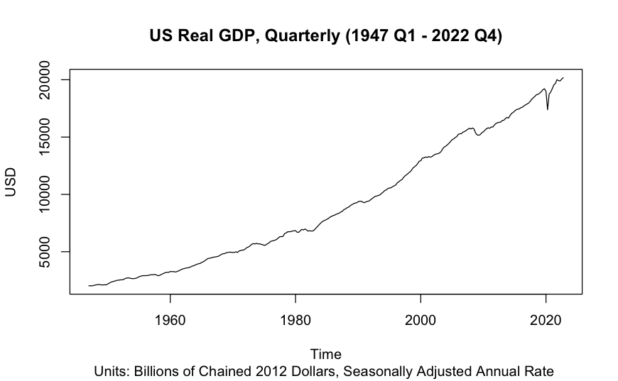

```r
US_real_GDP <- ts( data_3a$GDPC1, start = c(1947, 1), frequency = 4)
plot(US_real_GDP
     , main = "US Real GDP, Quarterly (1947 Q1 - 2022 Q4)"
     , sub = "Units: Billions of Chained 2012 Dollars, Seasonally Adjusted Annual Rate "
     , ylab = "USD"
     )
```

**Key Findings**  
Periodicity: Quarterly  
Units: Billions of Chained dollars as per 2012  
The underlying stochastic process is **not stationary**. There is an upward trend and all random variables do not have the same mean.

#### Part b: The exchange rate of the Japanese Yen against the US Dollar

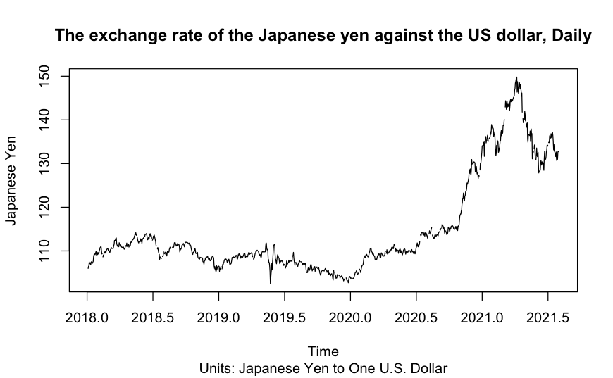

```r
yen_exch_rate <- ts( data = data_3b$DEXJPUS, start = c(2018,4,2), frequency = 365 )

plot(yen_exch_rate
     , main = "The exchange rate of the Japanese yen against the US dollar, Daily"
     , sub = "Units: Japanese Yen to One U.S. Dollar"
     , ylab = "Japanese Yen"
     )
```

**Key Findings**  
Periodicity: Daily  
Units: Japanese yen to 1 Dollar  
While between 2018 and 2020, the rate fluctuates within the same range, between 2020 and early 2021 there is a sharp upward trend and since 2021 there was a downward trend. All random variables do not have the same mean and variance, and covariance depends on time. Hence, the underlying processes are **non-stationary**.

#### Part c: The 10-year US Treasury constant maturity yield

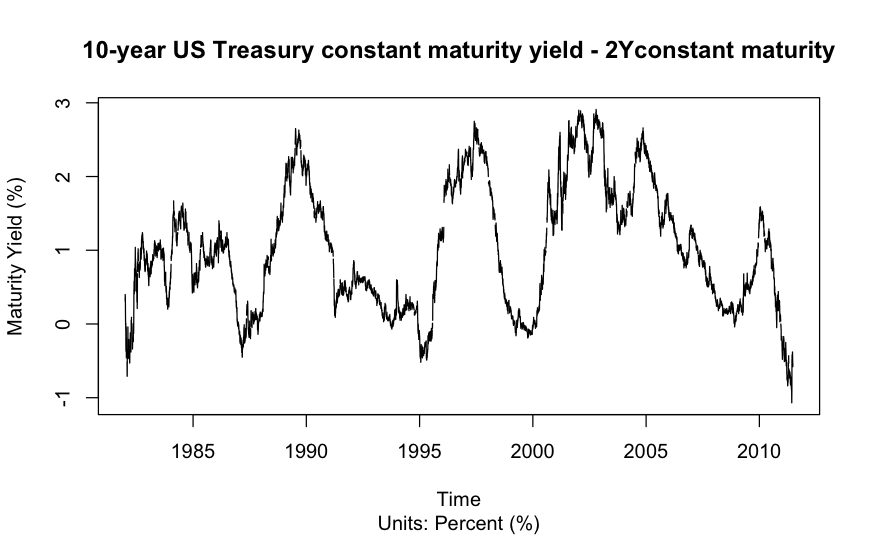

```r
US_treasury_maturity_yield_minus_2year <- ts( data = data_3c$T10Y2Y, start = c(1982, 1 , 4 ) ,frequency = 365)
US_treasury_maturity_yield_minus_3month<- ts( data = data_3c$T10Y3M, start = c(1982, 1 , 4 ),frequency = 365)

plot.ts( US_treasury_maturity_yield_minus_2year
     , main = "10-year US Treasury constant maturity yield - 2Yconstant maturity"
     , sub = "Units: Percent (%)"
     , ylab = "Maturity Yield (%)"
     )
```

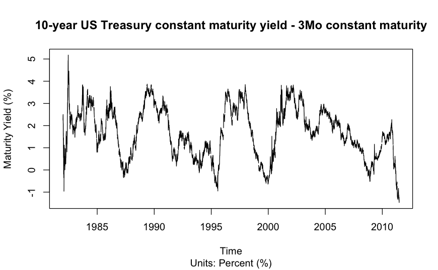

```r
plot.ts( US_treasury_maturity_yield_minus_3month
     , main = "10-year US Treasury constant maturity yield - 3Mo constant maturity"
     , sub = "Units: Percent (%)"
     , ylab = "Maturity Yield (%)"
     )
```

```r
NA
NA
```

We can see the peak and the bottom of the wave is not regular. Meanwhile, the range is unstable at the same time. Combining the finding from the plot and also the data display. We can conclude that this 10-year US treasury constant maturity yield is not stationary.

#### Part d: US unemployment Rate

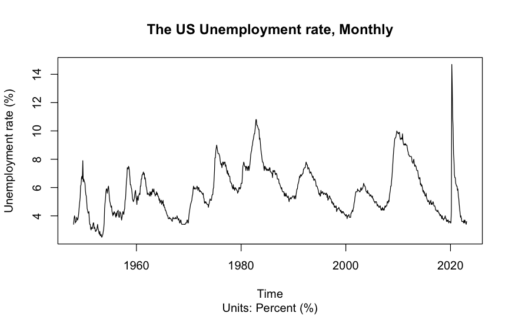

```r
US_unemployment_rate <- ts( data = data_3d$UNRATE, start = c(1948, 1 ) , end = c( 2023 , 2 ) ,frequency = 12)

plot.ts( US_unemployment_rate
     , main = "The US Unemployment rate, Monthly"
     , sub = "Units: Percent (%)"
     , ylab = "Unemployment rate (%)"
     )
```

```r
summary(US_unemployment_rate)
```

```
   Min. 1st Qu.  Median    Mean 3rd Qu.    Max.
  2.500   4.400   5.500   5.728   6.800  14.700
```

```r
cat( "Standard deviation for Unemployment Rate: ", sd(US_unemployment_rate))
```

```
Standard deviation for Unemployment Rate:  1.704625
```

**Key Findings**  
Periodicity: Monthly  
Units: Unemployment Rate as Percentage  
From 1980 to 2020 the time series **appears** to be first order weakly stationary since the mean appears to be constant and the values fluctuate across the mean (5.7%). It does not look second order stationary that is variance is different at different times. For instance, we can see that there are periods with higher fluctuations like the 1980s and 2020 where the variance is higher than say the 1960.  
**We would need to do a bit more analysis to understand whether it is second order weakly stationary.**